# Fisseha Berhane, PhD

#### Data Scientist

443-970-2353 fisseha@jhu.edu CV Resume

### Visualizing world cities using R

In this post, we will create a world map that shows world cities using **ggplot2**. We will get the cities and their attributies from [Wikipedia](https://en.wikipedia.org/wiki/List_of_cities_by_latitude). To scrape the data from [Wikipedia](https://en.wikipedia.org/wiki/List_of_cities_by_latitude), we will use the **rvest** R package, which is very user friendly for web scraping.

After we get the world cities data from Wikipedia, we will use the string manipulation packages **stringi** and **stringr**.

#### Load Required Libraries

```r
library(rvest)
library(stringi)
library(stringr)
library(ggplot2)
library(ggmap)
library(maptools)
library(maps)
```

### Mine the data from Wikipedia and process it.

```r
wiki= read_html("https://en.wikipedia.org/wiki/List_of_cities_by_latitude")

cities=data.frame(c())

for(i in seq(3,19)){
table=wiki %>%
  html_nodes("table") %>%
  .[[i]]%>%
  html_table(fill=T)
table=table[,1:5]
names(table)=c("Latitude","Longitude", "City","Province/State","Country")
cities=rbind(cities,table)
}

latlon=cities[,1:2]

latlon=str_replace_all(latlon, "[^[:alnum:]]", " ")

latlon=iconv(latlon, "latin1", "ASCII", sub="")
latlon=stri_sub(latlon,4)
lat=latlon[1]
lon=latlon[2]
lat=unlist(str_split(lat,"   "))
lon=unlist(str_split(lon,"   "))

z=as.data.frame(list(degree=c(),minute=c(),NS=c()))

for(i in 1:length(lat)){
  a=lat[i]
  a= unlist(str_split(a,"\\s+"))
  if(length(a)>3){
    if(nchar(a[1])==0){
      a=a[2:length(a)]
    }
  }
  b= as.data.frame(list(degree=as.numeric(as.character(a[1])),minute=as.numeric(as.character(a[2])),NS=a[3]))
  z=rbind(z,b)
}


lat=z

z=as.data.frame(list(degree=c(),minute=c(),NS=c()))
for(i in 1:length(lon)){
  a=lon[i]
  a= unlist(str_split(a,"\\s+"))
  if(length(a)>3){
    if(nchar(a[1])==0){
      a=a[2:length(a)]
    }
  }
  a= as.data.frame(list(degree=as.numeric(as.character(a[1])),minute=as.numeric(as.character(a[2])),NS=a[3]))
  z=rbind(z,a)
}
lon=z




lat[,2]=lat[,2]/60
lon[,2]=lon[,2]/60

lat[,1]=lat[,1]+lat[,2]
lon[,1]=lon[,1]+lon[,2]

for(i in 1:nrow(lat)){
  if(lat[i,3]=="S"){
    lat[i,1]=lat[i,1]*-1
  }
}

for(i in 1:nrow(lon)){
  if(lon[i,3]!="E"){
    lon[i,1]=lon[i,1]*-1
  }
}

Latitude=lat[,1]
Longitude=lon[,1]
```

#### Create base world map using **ggplot2**

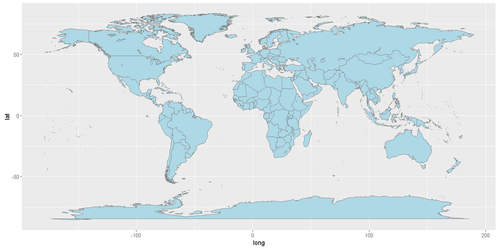

```r
mapWorld <- borders("world", colour="gray50", fill="lightblue") # create a layer of borders
wp<- ggplot() +   mapWorld
wp
```

#### Add cities to the base map

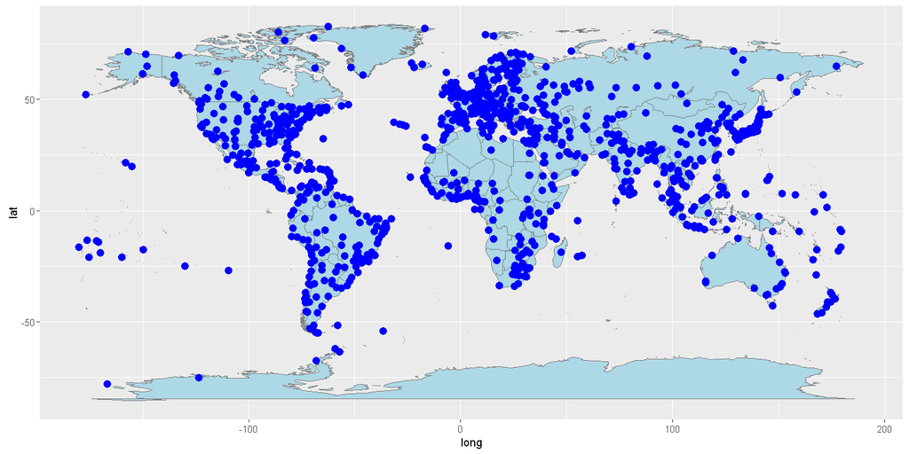

```r
wp <- wp+ geom_point(aes(x=Longitude,y=Latitude) ,color="blue", size=3)
wp
```

#### Add some enhancements

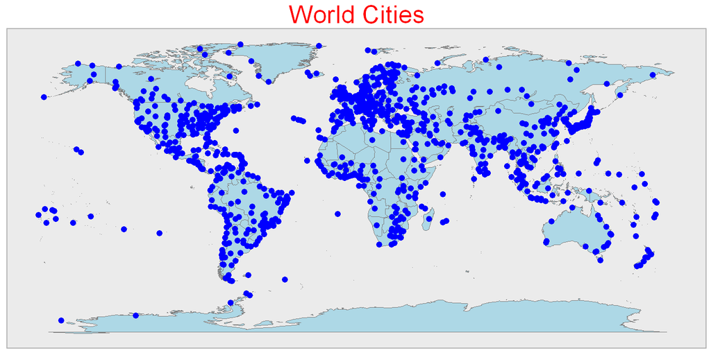

```r
wp+ ggtitle("World Cities")+theme(axis.text.y   = element_blank(),
                      line = element_blank(),
                      axis.text.x   = element_blank(),
                      axis.title.y  = element_blank(),
                      axis.title.x  = element_blank(),
                      panel.grid.major = element_blank(),
                      panel.grid.minor = element_blank(),
                      plot.title = element_text(vjust=1.5,size = 30,colour="Red"),
                      panel.border = element_rect(colour = "gray70", fill=NA, size=1))
```

### Interactive Map

The Tableau visualization below is made using the data created above with the R code. The cities are represented by points. If you hover over the circles, you can read the city and other associated attributes.

[figure not shown]

### Summary

In this blog post, we scrappped world cities with their latitude and longitude information from [Wikipedia](https://en.wikipedia.org/wiki/List_of_cities_by_latitude) using the **rvest** package and used the packages **stringi** and **stringr** for string manipulation. Finally, we used the **ggplot2** package to create the map of the world that shows world cities.

[comments powered by Disqus](http://disqus.com)